# R Notebook

## MINUTES_PREV_MONTH

Phone Minutes used in the previous month

| Predictor | MINUTES_PREV_MONTH |
| --- | --- |
| attribute type | Numerical |
| %Missing Values |  |
| Max | 16754 |
| Min | 0 |
| Mean | 864.3188406 |
| Mode | 0 |
| median | 98 |

MINUTES_PREV_MONTH Skewness

```r
(3 * (mean(churn_data$MINUTES_PREV_MONTH) - median(churn_data$MINUTES_PREV_MONTH)))/ sd(churn_data$MINUTES_PREV_MONTH)
```

```
## [1] 0.9312979
```

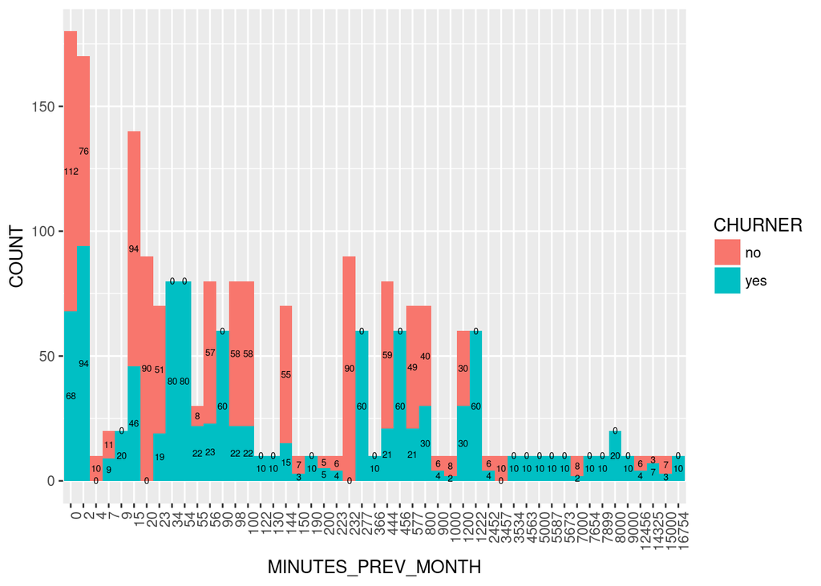

```r
plot_data <- data.frame(table(churn_data$MINUTES_PREV_MONTH, churn_data$CHURNER))
colnames(plot_data) <- c("MINUTES_PREV_MONTH", "CHURNER", "COUNT")
ggplot(data=plot_data, aes(x = MINUTES_PREV_MONTH, y=COUNT, fill = CHURNER, label=COUNT)) +
  geom_histogram(stat="identity", width = 1) +
  geom_text(size = 2, position = position_stack(vjust = 0.5))+
  theme(axis.text.x = element_text(angle = 90, hjust = 1))
```

## MINUTES_3MONTHS_AGO

Phone Minutes used in the 3 month PREVIOUS

| Predictor | MINUTES_3MONTHS_AGO |
| --- | --- |
| attribute type | Numerical |
| %Missing Values |  |
| Max | 12456 |
| Min | 0 |
| Mean | 452.7463768 |
| Mode | 0 |
| median | 97 |

MINUTES_3MONTHS_AGO Skewness

Right-skewness data – Is positive, as mean is greater than the median

```r
(3 * (mean(churn_data$MINUTES_3MONTHS_AGO) - median(churn_data$MINUTES_3MONTHS_AGO)))/ sd(churn_data$MINUTES_3MONTHS_AGO)
```

```
## [1] 0.9012361
```

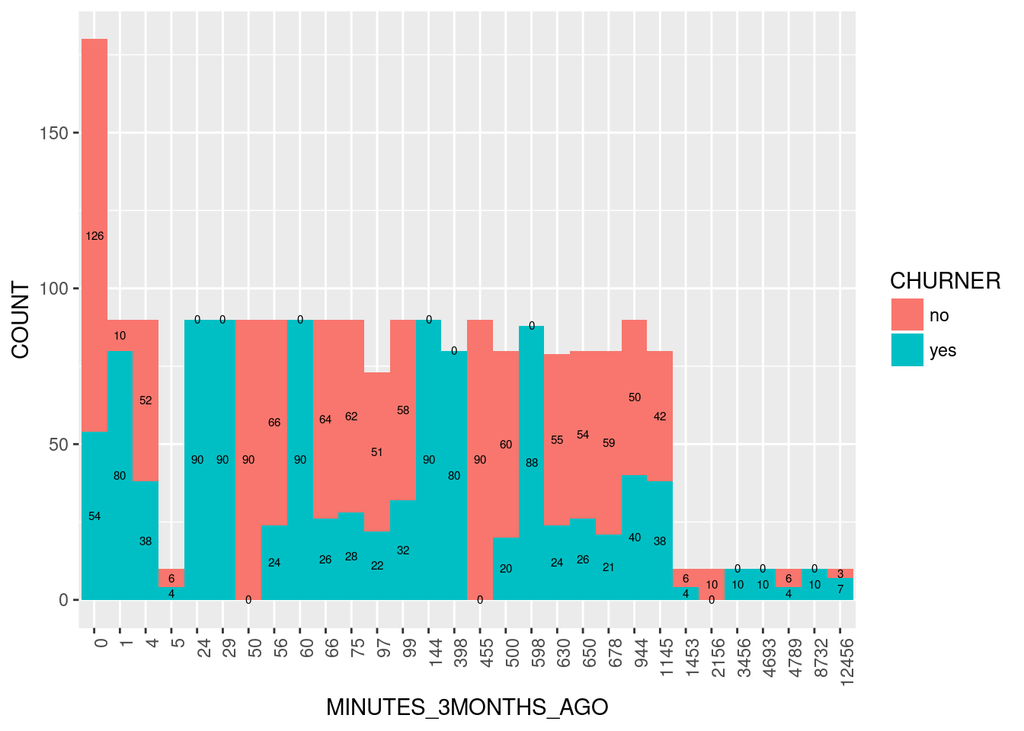

```r
plot_data <- data.frame(table(churn_data$MINUTES_3MONTHS_AGO, churn_data$CHURNER))
colnames(plot_data) <- c("MINUTES_3MONTHS_AGO", "CHURNER", "COUNT")
ggplot(data=plot_data, aes(x = MINUTES_3MONTHS_AGO, y=COUNT, fill = CHURNER, label=COUNT)) +
  geom_histogram(stat="identity", width = 1) +
  geom_text(size = 2, position = position_stack(vjust = 0.5))+
  theme(axis.text.x = element_text(angle = 90, hjust = 1))
```

## CUST_MOS

The number of continuous months the Customer is with the provider

Predictor

CUST_MOS

attribute type

Numerical

%Missing Values

```
                0
```

Max

50

Min

1

Mean

16.0545894

Mode

11

median

11

CUST_MOS Skewness

Right-skewness data – Is positive, as mean is greater than the median

```r
(3 * (mean(churn_data$CUST_MOS) - median(churn_data$CUST_MOS)))/ sd(churn_data$CUST_MOS)
```

```
## [1] 1.132926
```

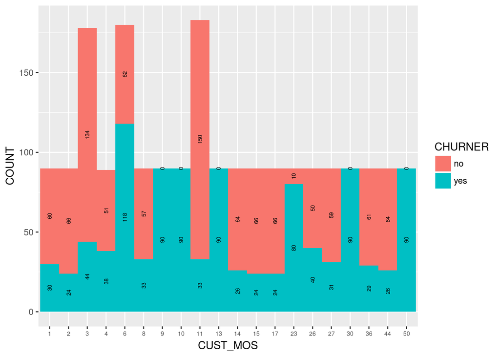

```r
plot_data <- data.frame(table(churn_data$CUST_MOS, churn_data$CHURNER))
colnames(plot_data) <- c("CUST_MOS", "CHURNER", "COUNT")
ggplot(data=plot_data, aes(x = CUST_MOS, y=COUNT, fill = CHURNER, label=COUNT)) +
  geom_histogram(stat="identity", width = 1) +
  geom_text(size = 2, angle = 90, position = position_stack(vjust = 0.5))+
  theme(axis.text.x = element_text(size=6, hjust = .5))
```

## TOT_MINUTES_USAGE

The total number of minutes used to date

[output not shown]

TOT_MINUTES_USAGE Skewness

Right-skewness data – Is positive, as mean is greater than the median

```r
(3 * (mean(churn_data$TOT_MINUTES_USAGE) - median(churn_data$TOT_MINUTES_USAGE)))/ sd(churn_data$TOT_MINUTES_USAGE)
```

```
## [1] 1.089144
```

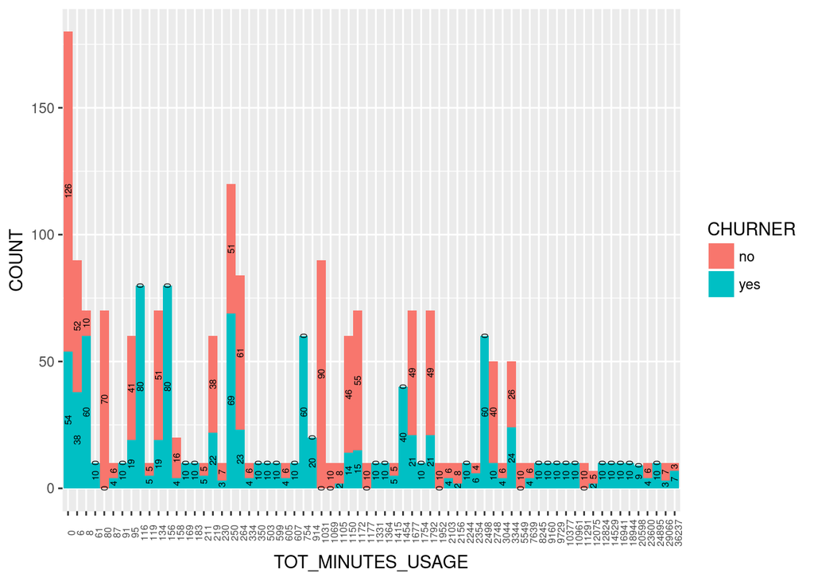

```r
plot_data <- data.frame(table(churn_data$TOT_MINUTES_USAGE, churn_data$CHURNER))
colnames(plot_data) <- c("TOT_MINUTES_USAGE", "CHURNER", "COUNT")
ggplot(data=plot_data, aes(x = TOT_MINUTES_USAGE, y=COUNT, fill = CHURNER, label=COUNT)) +
  geom_histogram(stat="identity", width = 1) +
  geom_text(size = 2, angle = 90, position = position_stack(vjust = 0.5))+
  theme(axis.text.x = element_text(size=6, angle = 90, hjust = .5))
```

## NUM_LINES

The number of fixed lines the customer has leased.

| Predictor | NUM_LINES |
| --- | --- |
| attribute type | Numeric |
| %Missing Values | 0% |
| Max | 3 |
| Min | 1 |
| Mean | 1.3913043 |
| Mode | 1 |
| median | 1 |
| Standard deviation | 0.5703498 |

NUM_LINES Skewness

Right-skewness data – Is positive, as mean is greater than the median

```r
(3 * (mean(churn_data$NUM_LINES) - median(churn_data$NUM_LINES)))/ sd(churn_data$NUM_LINES)
```

```
## [1] 2.058233
```

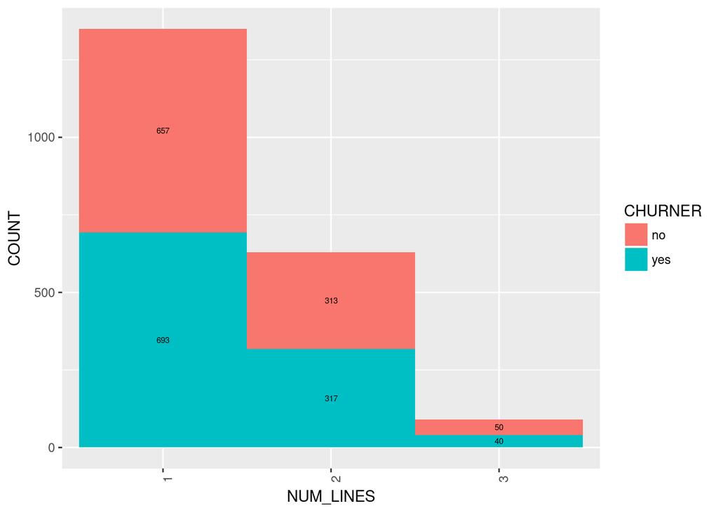

```r
plot_data <- data.frame(table(churn_data$NUM_LINES, churn_data$CHURNER))
colnames(plot_data) <- c("NUM_LINES", "CHURNER", "COUNT")
ggplot(data=plot_data, aes(x = NUM_LINES, y=COUNT, fill = CHURNER, label=COUNT)) +
  geom_histogram(stat="identity", width = 1) +
  geom_text(size = 2, position = position_stack(vjust = 0.5))+
  theme(axis.text.x = element_text(angle = 90, hjust = 1))
```

# Skewness for numeric data

Right-skewness data – Is positive, as mean is greater than the median Left skewness data – Mean is smaller than the median, generating negative values Perfectly symmetric data – mean, median and mode are equal, so skewness is zero

```r
(3 * (mean(churn_data$MINUTES_3MONTHS_AGO) - median(churn_data$MINUTES_3MONTHS_AGO)))/ sd(churn_data$MINUTES_3MONTHS_AGO)
```

```
## [1] 0.9012361
```

```r
(3 * (mean(churn_data$MINUTES_PREV_MONTH) - median(churn_data$MINUTES_PREV_MONTH)))/ sd(churn_data$MINUTES_PREV_MONTH)
```

```
## [1] 0.9312979
```

```r
(3 * (mean(churn_data$MINUTES_CURR_MONTH) - median(churn_data$MINUTES_CURR_MONTH)))/ sd(churn_data$MINUTES_CURR_MONTH)
```

```
## [1] 0.956244
```

```r
(3 * (mean(churn_data$TOT_MINUTES_USAGE) - median(churn_data$TOT_MINUTES_USAGE)))/ sd(churn_data$TOT_MINUTES_USAGE)
```

```
## [1] 1.089144
```

```r
(3 * (mean(churn_data$NUM_LINES) - median(churn_data$NUM_LINES)))/ sd(churn_data$NUM_LINES)
```

```
## [1] 2.058233
```

```r
(3 * (mean(churn_data$CUST_MOS) - median(churn_data$CUST_MOS)))/ sd(churn_data$CUST_MOS)
```

```
## [1] 1.132926
```

# Graphical methods to identify outliers

## MINUTES_3MONTHS_AGO

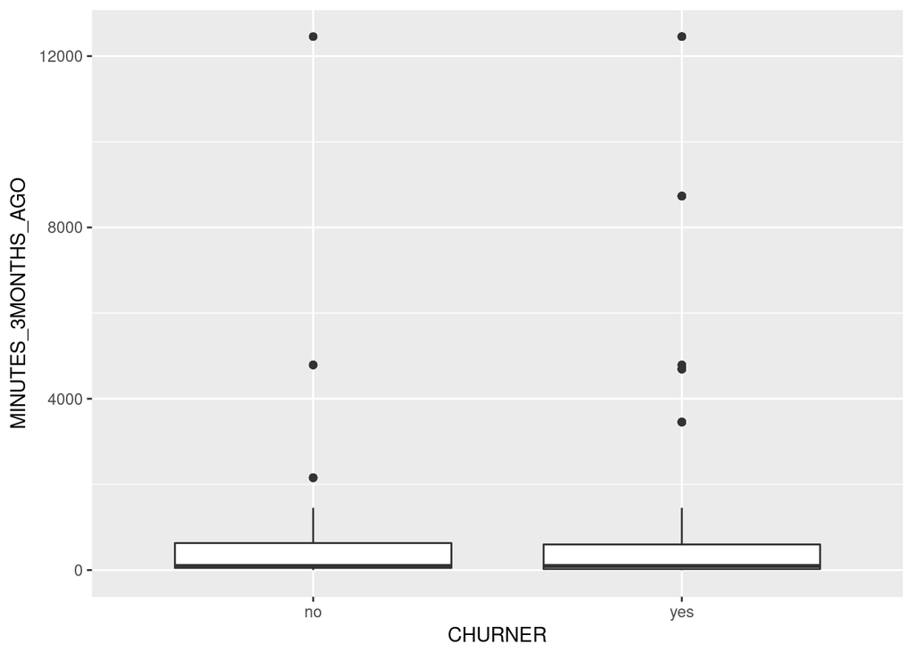

```r
ggplot(data=churn_data, aes(x=CHURNER, y=MINUTES_3MONTHS_AGO))+ geom_boxplot()
```

## MINUTES_PREV_MONTH

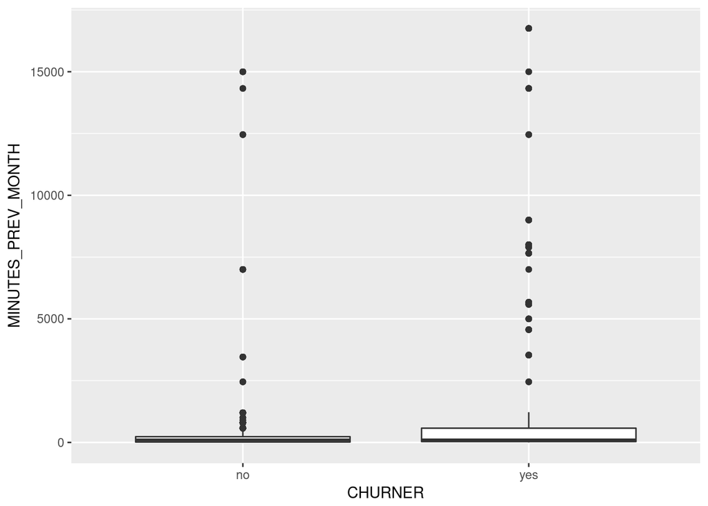

```r
ggplot(data=churn_data, aes(x=CHURNER, y=MINUTES_PREV_MONTH))+ geom_boxplot()
```

## MINUTES_CURR_MONTH

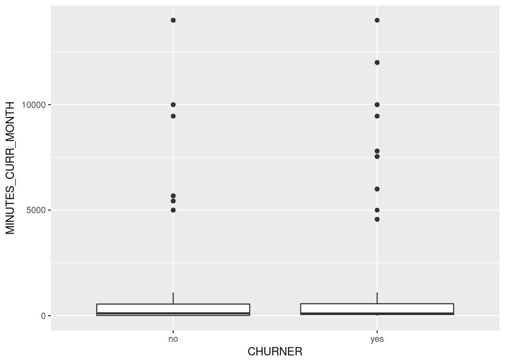

```r
ggplot(data=churn_data, aes(x=CHURNER, y=MINUTES_CURR_MONTH))+ geom_boxplot()
```

## TOT_MINUTES_USAGE

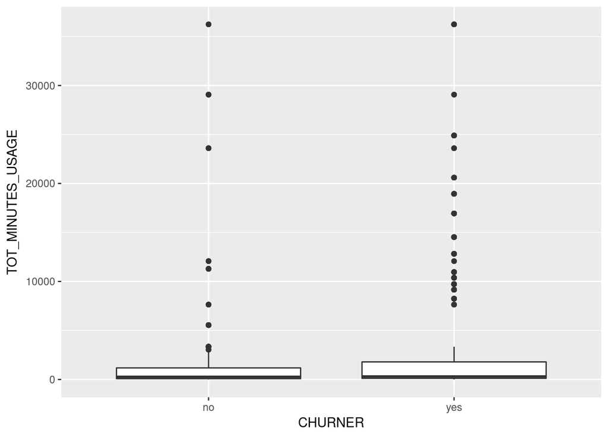

```r
ggplot(data=churn_data, aes(x=CHURNER, y=TOT_MINUTES_USAGE))+ geom_boxplot()
```

## NUM_LINES

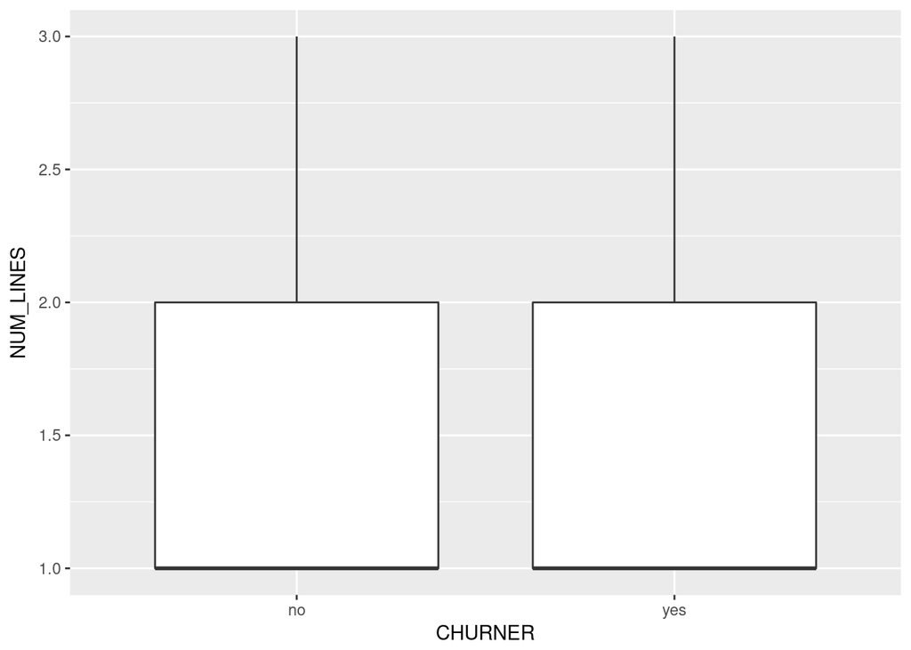

```r
ggplot(data=churn_data, aes(x=CHURNER, y=NUM_LINES))+ geom_boxplot()
```

## CUST_MOS

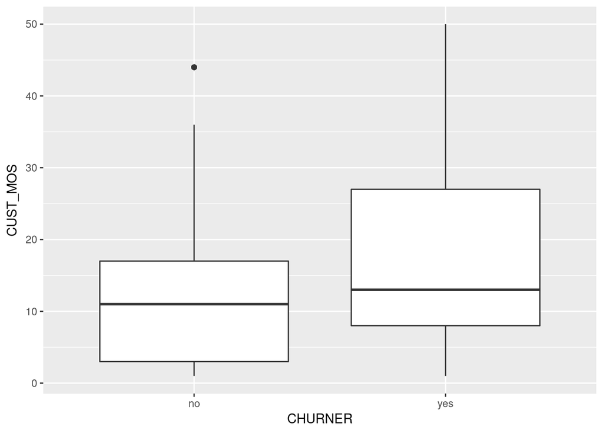

```r
ggplot(data=churn_data, aes(x=CHURNER, y=CUST_MOS))+ geom_boxplot()
```

# Mathematically identifying outliers

Choose a numeric predictor variable that has possible outliers based on your analysis in 2 above. Use the IQR method and Z-Score Standardisation method to identify outliers. Discuss your findings.

IQR method

```r
minutesQuartileTolerance <- 1.5* IQR(churn_data$TOT_MINUTES_USAGE)
minutesLowerQuantile <- quantile(churn_data$TOT_MINUTES_USAGE, 0.25)
minutesUpperQuantile <- quantile(churn_data$TOT_MINUTES_USAGE, 0.75)

print("lower outliers")
```

```
## [1] "lower outliers"
```

```r
churn_data$TOT_MINUTES_USAGE[churn_data$TOT_MINUTES_USAGE < (minutesLowerQuantile - minutesQuartileTolerance)]
```

```
## numeric(0)
```

```r
print("upper outliers")
```

```
## [1] "upper outliers"
```

```r
churn_data$TOT_MINUTES_USAGE[churn_data$TOT_MINUTES_USAGE > (minutesUpperQuantile + minutesQuartileTolerance)]
```

```
##   [1] 18944 14529 12824 23600 10961 20598 29066  9160 12075 11291  7639
##  [12] 36237  9729 16941 10377 11291  7639 36237  9729  5549 16941 10377
##  [23]  5549 24895  8245  5549 24895  8245 16941 10377  5549 24895  8245
##  [34] 18944 14529 12824 23600 10961 20598 16941 10377 24895  8245  5549
##  [45] 18944 14529 12824 23600 10961 20598 29066  9160  5549 12075 11291
##  [56] 18944 14529 12824 23600 10961 20598 29066  9160 11291  7639 36237
##  [67]  9729 29066  9160 12075 11291  7639 36237  9729 24895  8245  7639
##  [78] 36237  9729 16941 10377 24895  8245  5549 18944 14529 12824 23600
##  [89] 10961 29066  5549  9160 12075 11291  7639 36237  9729  5549 16941
## [100] 10377 18944 14529 12824  5549 23600 10961 20598 29066  9160 11291
## [111]  7639 36237  9729 16941 29066  9160 12075 11291  7639 36237  9729
## [122] 16941 10377 24895 10961 20598 29066  9160 11291  7639 36237  9729
## [133] 16941 10377 24895  8245 10377 24895  8245 18944 14529 12824 23600
## [144] 10961 20598  8245 18944 14529 12824 23600 24895  8245 18944 14529
## [155] 12824 23600 10961 20598 29066  9160 12075 18944 14529 12824 23600
## [166] 10961 20598 29066  9160 12075 11291  7639 36237  9729 16941 10377
```

zScore Standardisation method

```r
# zScore Standardisation
zscore.TOT_MINUTES_USAGE <-(churn_data$TOT_MINUTES_USAGE - mean(churn_data$TOT_MINUTES_USAGE))/sd(churn_data$TOT_MINUTES_USAGE)
summary(zscore.TOT_MINUTES_USAGE)
```

```
##     Min.  1st Qu.   Median     Mean  3rd Qu.     Max.
## -0.41710 -0.39340 -0.36300  0.00000 -0.07373  7.00300
```

```r
zscore.TOT_MINUTES_USAGE[zscore.TOT_MINUTES_USAGE < -3 | zscore.TOT_MINUTES_USAGE > 3]
```

```
##  [1] 3.461758 4.415093 3.800421 5.534279 7.002570 3.051636 7.002570
##  [8] 3.051636 4.680249 4.680249 3.051636 4.680249 3.461758 4.415093
## [15] 3.800421 3.051636 4.680249 3.461758 4.415093 3.800421 5.534279
## [22] 3.461758 4.415093 3.800421 5.534279 7.002570 5.534279 7.002570
## [29] 4.680249 7.002570 3.051636 4.680249 3.461758 4.415093 5.534279
## [36] 7.002570 3.051636 3.461758 4.415093 3.800421 5.534279 7.002570
## [43] 3.051636 5.534279 7.002570 3.051636 4.680249 3.800421 5.534279
## [50] 7.002570 3.051636 4.680249 4.680249 3.461758 4.415093 3.800421
## [57] 3.461758 4.415093 4.680249 3.461758 4.415093 3.800421 5.534279
## [64] 3.461758 4.415093 3.800421 5.534279 7.002570 3.051636
```

# Correcting skewness

```r
# calculate skewness
TOT_MINUTES_USAGESkewness <- (3 * (mean(churn_data$TOT_MINUTES_USAGE) - median(churn_data$TOT_MINUTES_USAGE)))/ sd(churn_data$TOT_MINUTES_USAGE)
TOT_MINUTES_USAGESkewness
```

```
## [1] 1.089144
```

Natural Log Transformation

```r
# Natural Log Transformation
natlog.TOT_MINUTES_USAGE <- log(churn_data$TOT_MINUTES_USAGE[churn_data$TOT_MINUTES_USAGE > 0])

# applying log function to skewness
logTOT_MINUTES_USAGESkewness <- (3 * (mean(natlog.TOT_MINUTES_USAGE) - median(natlog.TOT_MINUTES_USAGE)))/ sd(natlog.TOT_MINUTES_USAGE)
logTOT_MINUTES_USAGESkewness
```

```
## [1] -0.7042918
```

Square Root Transformation

```r
# Square Root Transformation
sqrt.TOT_MINUTES_USAGE <- sqrt(churn_data$TOT_MINUTES_USAGE)
# applying sqr root function to skewness

sqrTOT_MINUTES_USAGESkewness <- (3 * (mean(sqrt.TOT_MINUTES_USAGE) - median(sqrt.TOT_MINUTES_USAGE)))/ sd(sqrt.TOT_MINUTES_USAGE)
sqrTOT_MINUTES_USAGESkewness
```

```
## [1] 1.289714
```

zScore Standardisation

```r
# zScore Standardisation
zscore.TOT_MINUTES_USAGE <-(churn_data$TOT_MINUTES_USAGE - mean(churn_data$TOT_MINUTES_USAGE))/sd(churn_data$TOT_MINUTES_USAGE)

# applying zScore function to skewness
zscore.TOT_MINUTES_USAGE <- (3 * (mean(zscore.TOT_MINUTES_USAGE) - median(zscore.TOT_MINUTES_USAGE)))/ sd(zscore.TOT_MINUTES_USAGE)
zscore.TOT_MINUTES_USAGE
```

```
## [1] 1.089144
```

# 2D Scatter plots to investigate correlation

2D Scatter plots to investigate correlation between numeric variables

## TOT_MINUTES_USAGE vs CUST_MOS

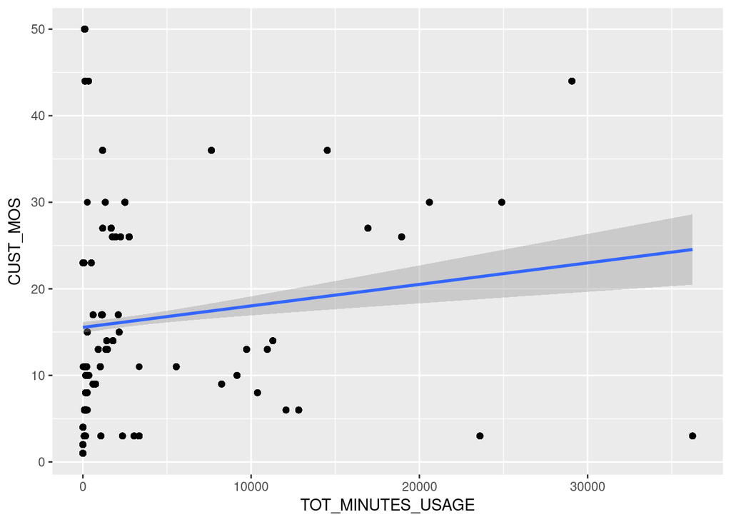

```r
ggplot(churn_data, aes(x=TOT_MINUTES_USAGE, y=CUST_MOS)) +
    geom_point() +
    geom_smooth(method=lm)
```

Correlation

```r
cor(x=churn_data$TOT_MINUTES_USAGE, y=churn_data$CUST_MOS, use="all.obs", method="pearson")
```

```
## [1] 0.09055857
```

```r
# http://www.statmethods.net/stats/correlations.html
```

## TOT_MINUTES_USAGE vs MINUTES_CURR_MONTH

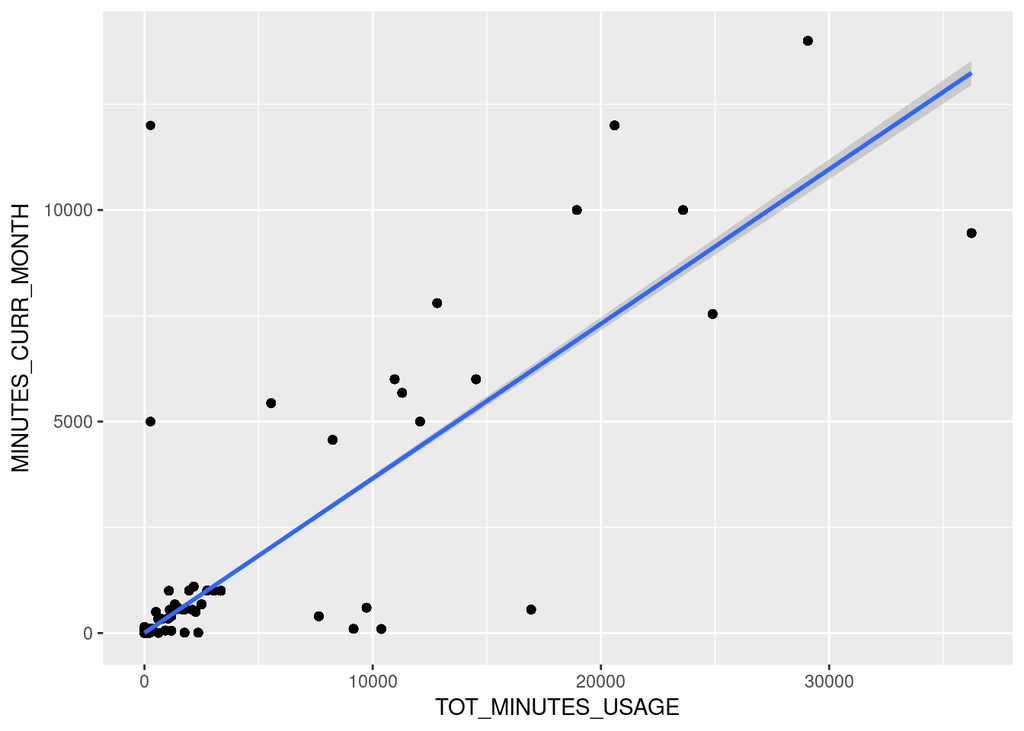

```r
ggplot(churn_data, aes(x=TOT_MINUTES_USAGE, y=MINUTES_CURR_MONTH)) +
    geom_point() +
    geom_smooth(method=lm)
```

Correlation

```r
cor(x=churn_data$TOT_MINUTES_USAGE, y=churn_data$MINUTES_CURR_MONTH, use="all.obs", method="pearson")
```

```
## [1] 0.8844237
```

```r
# http://www.statmethods.net/stats/correlations.html
```

## TOT_MINUTES_USAGE vs MINUTES_PREV_MONTH

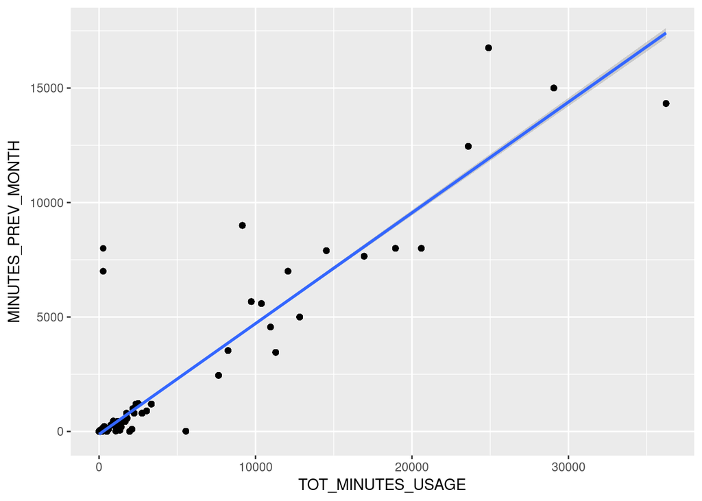

```r
ggplot(churn_data, aes(x=TOT_MINUTES_USAGE, y=MINUTES_PREV_MONTH)) +
    geom_point() +
    geom_smooth(method=lm)
```

Correlation

```r
cor(x=churn_data$TOT_MINUTES_USAGE, y=churn_data$MINUTES_PREV_MONTH, use="all.obs", method="pearson")
```

```
## [1] 0.9568583
```

```r
# http://www.statmethods.net/stats/correlations.html
```

## TOT_MINUTES_USAGE vs MINUTES_3MONTHS_AGO

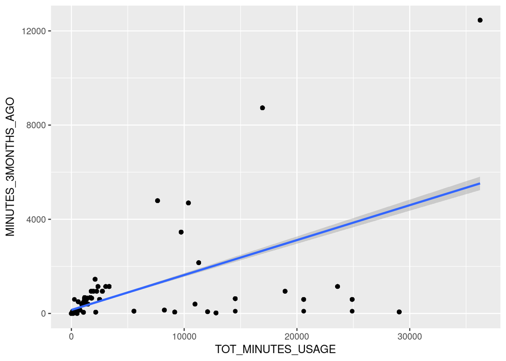

```r
ggplot(churn_data, aes(x=TOT_MINUTES_USAGE, y=MINUTES_3MONTHS_AGO)) +
    geom_point() +
    geom_smooth(method=lm)
```

Correlation

```r
cor(x=churn_data$TOT_MINUTES_USAGE, y=churn_data$MINUTES_3MONTHS_AGO, use="all.obs", method="pearson")
```

```
## [1] 0.611558
```

```r
# http://www.statmethods.net/stats/correlations.html
```

## TOT_MINUTES_USAGE vs NUM_LINES

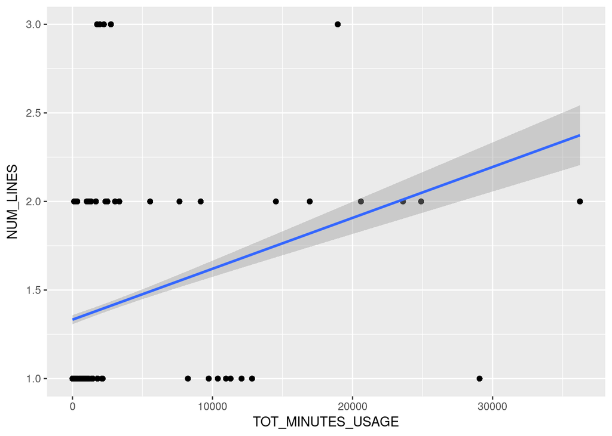

```r
ggplot(churn_data, aes(x=TOT_MINUTES_USAGE, y=NUM_LINES)) +
    geom_point() +
    geom_smooth(method=lm)
```

Correlation

```r
cor(x=churn_data$TOT_MINUTES_USAGE, y=churn_data$NUM_LINES, use="all.obs", method="pearson")
```

```
## [1] 0.2460581
```

```r
# http://www.statmethods.net/stats/correlations.html
```

## CUST_MOS vs MINUTES_CURR_MONTH

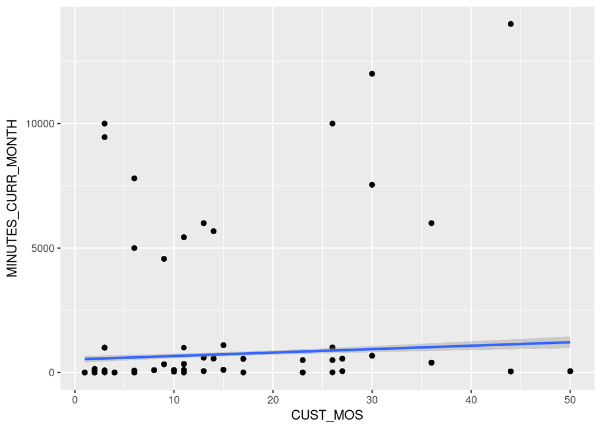

```r
ggplot(churn_data, aes(x=CUST_MOS, y=MINUTES_CURR_MONTH)) +
    geom_point() +
    geom_smooth(method=lm)
```

```r
cor(x=churn_data$TOT_MINUTES_USAGE, y=churn_data$MINUTES_CURR_MONTH, use="all.obs", method="pearson")
```

```
## [1] 0.8844237
```

```r
# http://www.statmethods.net/stats/correlations.html
```

## CUST_MOS vs MINUTES_PREV_MONTH

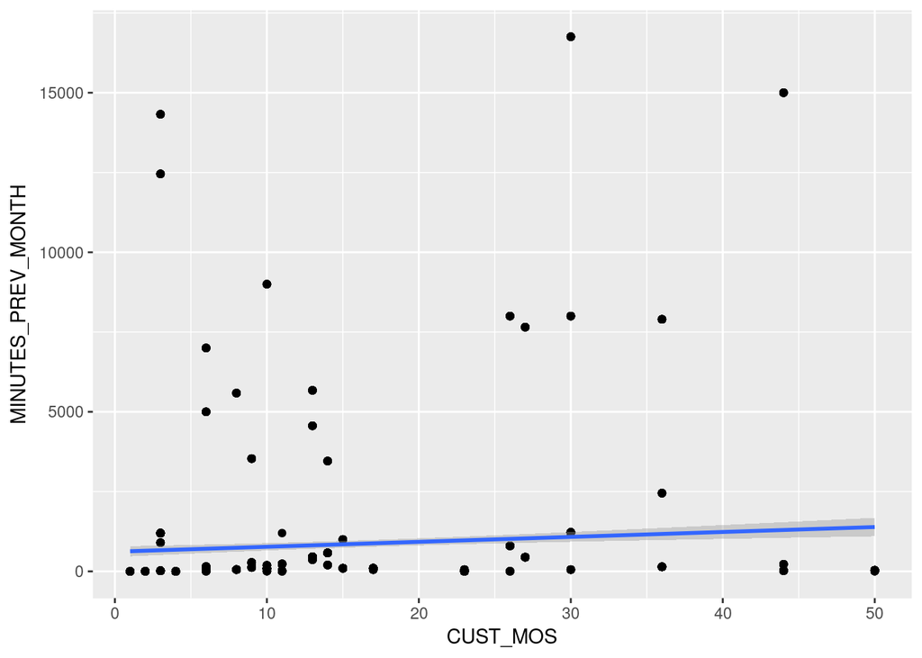

```r
ggplot(churn_data, aes(x=CUST_MOS, y=MINUTES_PREV_MONTH)) +
    geom_point() +
    geom_smooth(method=lm)
```

```r
cor(x=churn_data$TOT_MINUTES_USAGE, y=churn_data$MINUTES_PREV_MONTH, use="all.obs", method="pearson")
```

```
## [1] 0.9568583
```

```r
# http://www.statmethods.net/stats/correlations.html
```

## CUST_MOS vs MINUTES_3MONTHS_AGO

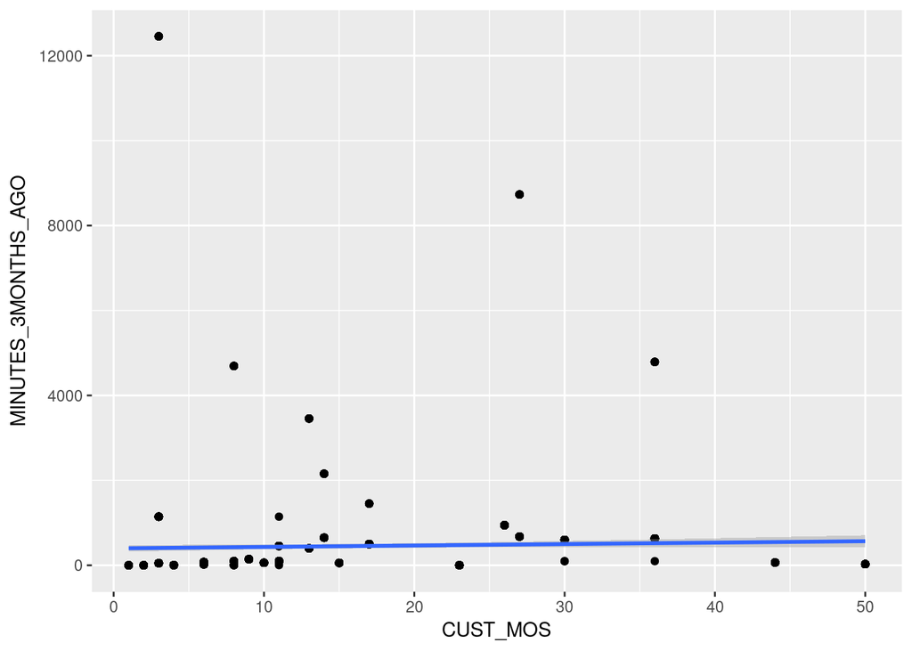

```r
ggplot(churn_data, aes(x=CUST_MOS, y=MINUTES_3MONTHS_AGO)) +
    geom_point() +
    geom_smooth(method=lm)
```

Correlation

```r
cor(x=churn_data$CUST_MOS, y=churn_data$MINUTES_3MONTHS_AGO, use="all.obs", method="pearson")
```

```
## [1] 0.03824096
```

```r
# http://www.statmethods.net/stats/correlations.html
```

## CUST_MOS vs NUM_LINES

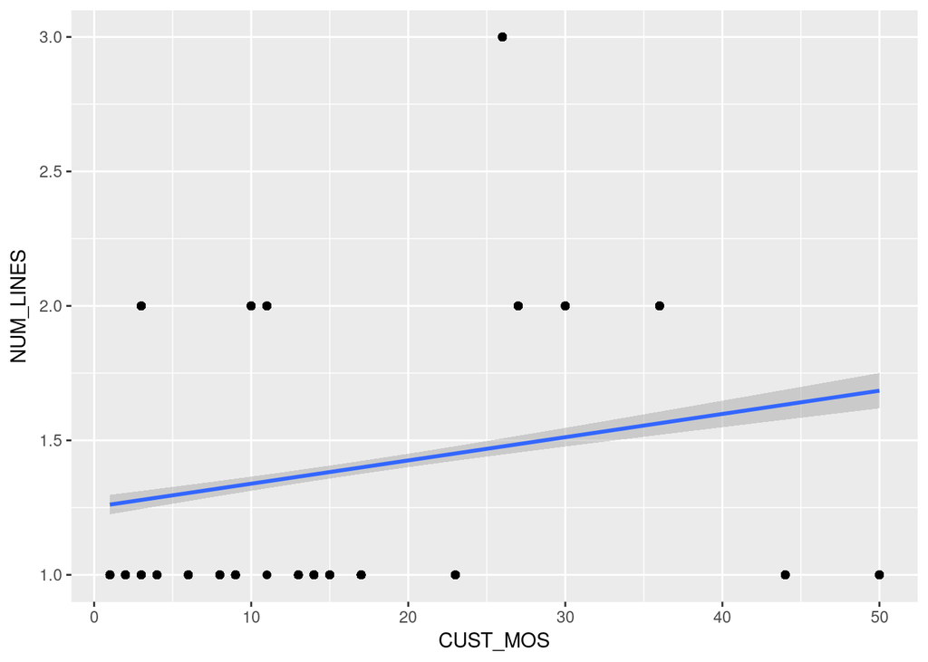

```r
ggplot(churn_data, aes(x=CUST_MOS, y=NUM_LINES)) +
    geom_point() +
    geom_smooth(method=lm)
```

Correlation

```r
cor(x=churn_data$CUST_MOS, y=churn_data$NUM_LINES, use="all.obs", method="pearson")
```

```
## [1] 0.2028409
```

```r
# http://www.statmethods.net/stats/correlations.html
```